# Homework 9

Anthony Cunningham

April 22, 2019

# 1 Economic Data

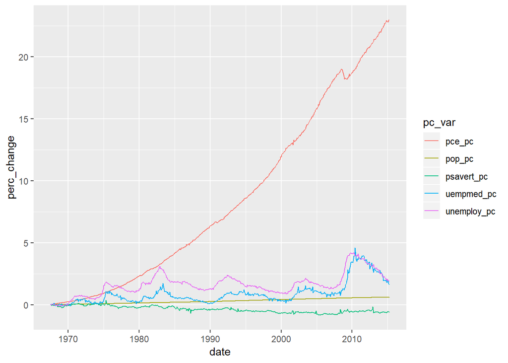

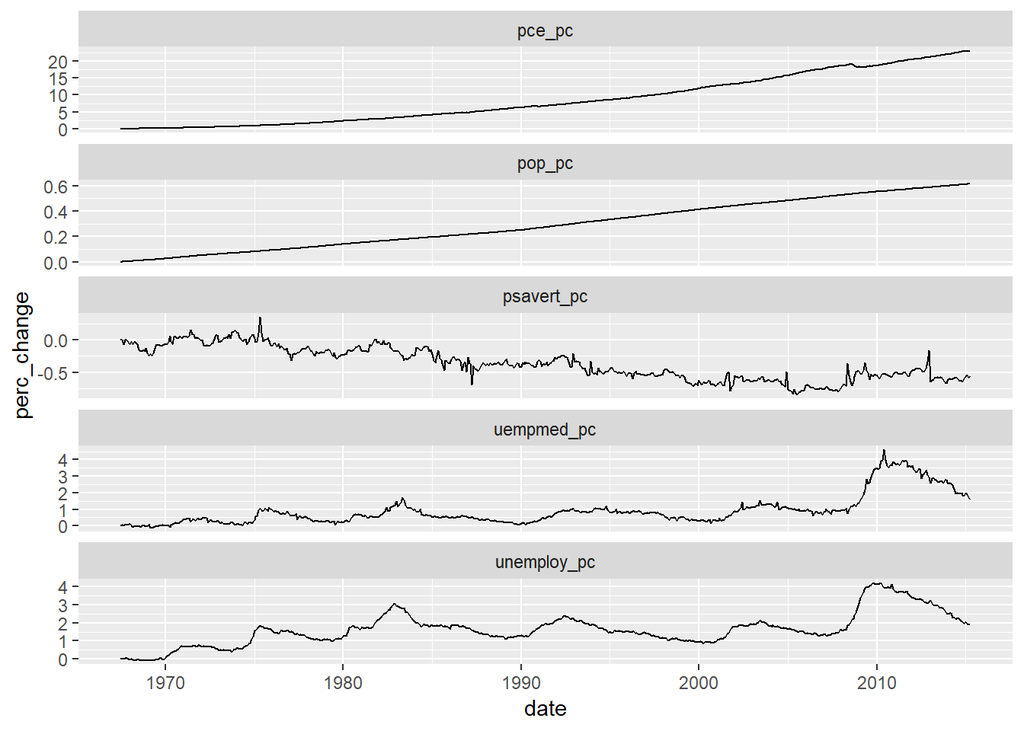

An interesting feature in the economic data are the stark contrasts in how some of these variables change. For instance, the Personal Consumption Expenditures and Population variables have both consistently and steadily increased (with the exception of a minor blip in expenditures following the 2008 financial crisis), while Savings Rates and both Unemployment measures have fluctuated in a rougly cyclical fashion. While these cyclical patterns are noticeable on the former plot, this cyclical nature really stands out when used in a trellis display. With just one plot, the first thing that stands out is the massive growth rate in Consumption, limiting the ability for the viewer to notice the cyclical nature of the Unemployment observations.

# 2 Florida Death Penalty Data

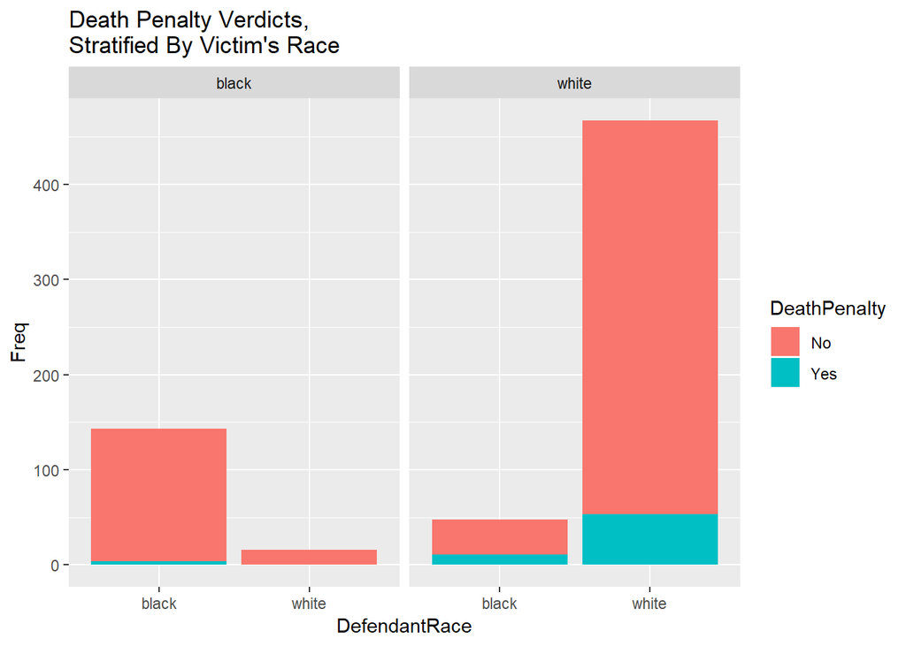

From this Stacked Bar Chart, we notice that “Yes” Death Penalty Verdicts are lower when the victim is Black than when the victim is White, regardless of Defendant’s Race. However, this could just be due to the large differences in frequency, as a lot more White victims appear in this dataset. Perhaps if we compared proportions, we could see a potentially significant difference.

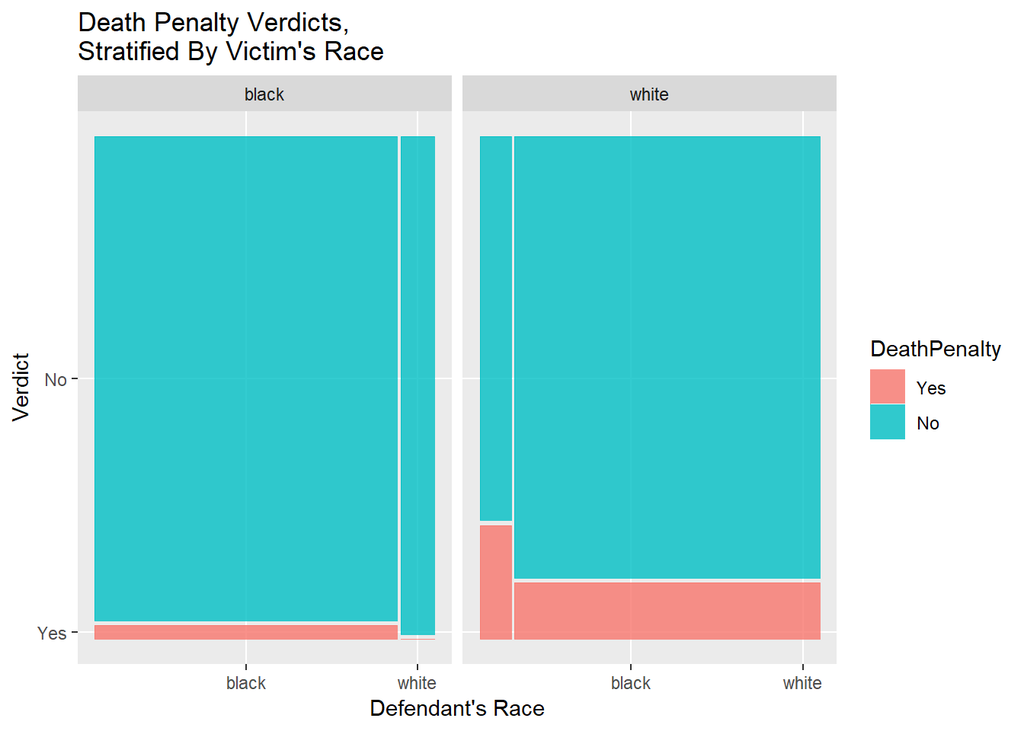

From this Spline Plot, we see that the proportion of “Yes” Death Penalty verdicts are lower when the victim is Black than when the victim is White, regardless of Defendant’s Race. This is consistent with our intuition from the prior Stacked Bar Chart. Visually, there seems to be some dependence between Verdict and Victim Race, but is this statistically significant?

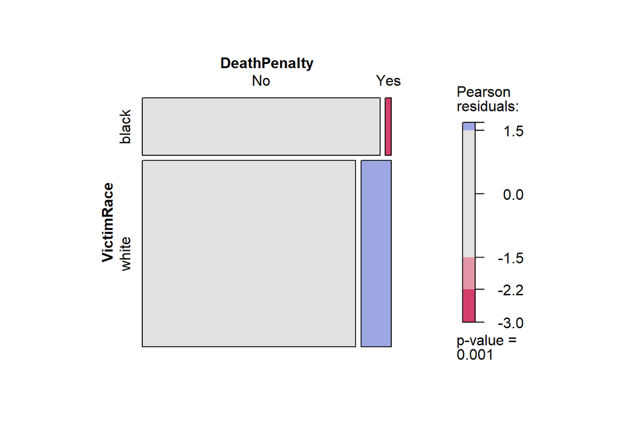